# Lipid biomarkers predicting depression

## 0.1 Preliminaries

```r
library(knitr); library(rmdformats)

## Global options
opts_chunk$set(comment = NA,
               warning = FALSE,
               message = FALSE)
#opts_knit$set(width=75)
```

```r
library(arm)
library(leaps)
library(modelr)
library(tableone)
library(pander)
library(ROCR)
library(skimr)
library(rms)
library(broom)
library(simputation)
library(tidyverse)
```

# 1 Task 1: Data Source

The raw data for this project comes from NHANES datasets published on CDC website. NHANES is a series of health and nutrition surveys conducted yearly in noninstitutionalized civilian resident population of the United State. Data from 2013-2014 cycle was used in this project.

## 1.1 Background of the study

Mental health issues such as depression are common in the US. In 2016, 6.7% of all adults in the US had at least one major depressive episode. Despite the high prevalence and significant impact on quality of life, the pathophysiolgic mechanism of depression remains unclear. Previous literature has suggested a possible link between atherosclerotic disease and depression.

In this study, I will investigate the role of lipid biomarkers for depression. Serum levels of lipid biomarkers such as toltal cholesterol, HDL, LDL, triglycerids are convenient and affordable tests. I will examine which of these biomarkers is effective in predicting depressive symptoms.

# 2 Task 2: Load and Tidy the Data

## 2.1 Data Load

```r
lipid <- read.csv("lipid_combined.csv") %>% tbl_df()
lipid
```

```
# A tibble: 2,840 x 33
       X    ID Gender   Age  Race Education Income Interest  Down Sleep
   <int> <int>  <int> <int> <int>     <int>  <int>    <int> <int> <int>
 1     1 73559      1    72     3         4     10        0     0     0
 2     2 73561      2    73     3         5     15        2     1     0
 3     3 73564      2    61     3         5     10        0     1     0
 4     4 73568      2    26     3         5     15        0     0     0
 5     5 73574      2    33     6         5      8        1     0     0
 6     6 73577      1    32     1         1      5        0     0     0
 7     7 73578      1    18     1        NA      5        0     0     0
 8     8 73580      2    38     4         3     12        0     0     0
 9     9 73581      1    50     6         5     15        0     0     0
10    10 73596      2    57     6         5     15        0     0     0
# ... with 2,830 more rows, and 23 more variables: Tired <int>, Appetite
#   <int>, Bad <int>, Concentrate <int>, Slow <int>, Dead <int>, Difficult
#   <int>, MHvisit <int>, BMI <dbl>, Waist <dbl>, TC <int>, TG <int>, LDL
#   <int>, HDL <int>, APP <int>, Tfat <dbl>, Tsfat <dbl>, Tmsfat <dbl>,
#   Tpsfat <dbl>, Tchol <dbl>, Hichol <int>, Cholmed <int>, Onmed <int>
```

The `lipid` data contain 2840 rows and 33 columns. The variables were extracted from several datasets and combined into one file. Explanations of the variables can be found at https://wwwn.cdc.gov/nchs/nhanes/continuousnhanes/Overview.aspx?BeginYear=2013

## 2.2 Tidying, Data Cleaning and Data Management

```r
tidy_lipid <- lipid %>%
  filter(complete.cases(Dead)) %>%
  mutate(sex = Gender - 1,
         sex = factor(sex, levels=c(0,1), labels =c("male", "female")),
         MHvisit = MHvisit - 1,
         MHvisit = factor(MHvisit, levels=c(0,1), labels=c("yes", "no")),
         phq = Interest + Down + Appetite + Sleep + Slow + Dead + Concentrate + Bad + Tired,
         Hichol=factor(Hichol),
         Race=factor(Race)) %>%
  select(Age, sex, Race, TC, TG, LDL, APP, HDL, BMI, Waist, phq,  MHvisit, Hichol, Income)
```

## 2.3 Are there missing values?

```r
na.pattern(tidy_lipid)
```

```
pattern
00000000000000 00000000000001 00000000000100 00000000010000 00000000100000
          2332             27              4             56              6
00000000110000 00000100000000 00000110000000 00001110000000 00011111000000
            12             36              1              1             87
00011111010000 00011111110000 00011111110001
             7              4              1
```

```r
colSums(is.na(tidy_lipid))
```

```
    Age     sex    Race      TC      TG     LDL     APP     HDL     BMI
      0       0       0      99     100     137     101      99      23
  Waist     phq MHvisit  Hichol  Income
     80       0       4       0      28
```

- 2332 subjects are missing nothing: these are the “complete cases”.
- `TC` has 99 missing values (quantitative).
- `TG` has 100 missing values (quantitative).
- `LDL` has 137 missing values (quantitative).
- `APP` has 101 missing values (quantitative).
- `HDL` has 99 missing values (quantitative).
- `BMI` has 23 missing values (quantitative).
- `Wasit` has 80 missing values (quantitative).
- `MHvisit` has 4 missing values (binary:yes vs no)
- `Income` has 28 missing values

## 2.4 Impute the missing data

To impute the missing data, I’ll use predictive mean matching for the categorical data, and linear models approach for the quantitative data.

```r
set.seed(432008)

tidy_lipid <- tidy_lipid %>%
    mutate(MHvisit_n = as.numeric(MHvisit))
tidy_lipid %>% count(MHvisit_n, MHvisit)
```

```
# A tibble: 3 x 3
  MHvisit_n MHvisit     n
      <dbl> <fct>   <int>
1      1.00 yes       208
2      2.00 no       2362
3     NA    <NA>        4
```

```r
imp <- tidy_lipid %>%
  impute_lm(Income ~ Age + Race) %>%
  impute_pmm(MHvisit_n ~ phq) %>%
  impute_lm(Waist ~ Hichol + Race) %>%
  impute_lm(BMI ~ Waist+ Hichol) %>%
  impute_lm(HDL ~ BMI + Waist +Hichol) %>%
  impute_lm(APP ~ Hichol + HDL) %>%
  impute_lm(LDL ~ APP + Hichol) %>%
  impute_lm(TG ~ LDL + Hichol) %>%
  impute_lm(TC ~ LDL + Hichol)

imp <- imp %>%
    mutate(MHvisit = fct_recode(factor(MHvisit_n),
                                  "yes" = "1",
                                  "no" = "2"))
colSums(is.na(imp))
```

```
      Age       sex      Race        TC        TG       LDL       APP
        0         0         0         0         0         0         0
      HDL       BMI     Waist       phq   MHvisit    Hichol    Income
        0         0         0         0         0         0         0
MHvisit_n
        0
```

## 2.5 Add 3 new columns, `bmi_c`, `phq_c`, `income_c`.

```r
imp1 <- imp %>%
  mutate(bmi_c = case_when(
           BMI < 18.5 ~ "Underweight",
           BMI < 25 ~ "Normal",
           BMI < 30 ~ "Overweight",
           BMI >= 30 ~ "Obese"),
         bmi_c = factor(bmi_c),
         phq_c = case_when(
           phq <= 4 ~ "Minimal depression",
           phq <= 9 ~ "Mild depression",
           phq <= 14 ~ "Moderate depression",
           phq <=19 ~ "Moderately severe depression",
           phq >=20 ~ "Severe depression"),
         phq_c = factor(phq_c),
           income_c = case_when(
             Income <= 5 ~ "Below 25,000",
             Income <= 10 ~ "Below 75,000",
             Income >= 14 ~ "Above 75,000"),
         income_c = factor(income_c))%>%
  select(-Income, -MHvisit_n)
```

## 2.6 Randomly select 1000 observations to make the final dataset.

```r
set.seed(432001)
complete <- sample_n(imp1, size = 1000)
complete <- complete %>%
  mutate(subject=1:1000) %>%
  select(subject, everything())
```

# 3 Task 3: Tidied Tibble

Our tibble `complete` contains 1000 rows (subjects) and 17 columns (variables). Each variable is contained in a column, and each row represents a single subject. All variables now have appropriate types.

```r
complete
```

```
# A tibble: 1,000 x 17
   subject   Age sex    Race     TC    TG   LDL   APP   HDL   BMI Waist
     <int> <int> <fct>  <fct> <dbl> <dbl> <dbl> <dbl> <dbl> <dbl> <dbl>
 1       1    65 male   4       210 122    93.0  89.0  93.0  24.9  82.9
 2       2    43 male   4       192  79.0 112    94.0  64.0  35.6  98.9
 3       3    43 female 2       194 268   108   105    32.0  35.4 111
 4       4    61 female 3       188 121   107    84.0  57.0  43.3 140
 5       5    67 female 4       165  64.0  94.0  73.0  58.0  22.1  81.5
 6       6    56 female 3       157 214    71.0  69.0  43.0  53.0 147
 7       7    49 female 2       176  71.0 102    85.0  60.0  41.0 126
 8       8    50 male   2       184 143   114   106    41.0  30.2 106
 9       9    80 female 3       173  47.0  73.0  59.0  91.0  31.5 118
10      10    74 female 3       187 117   106    86.0  58.0  27.2  96.1
# ... with 990 more rows, and 6 more variables: phq <int>, MHvisit <fct>,
#   Hichol <fct>, bmi_c <fct>, phq_c <fct>, income_c <fct>
```

```r
skim_with(numeric = list(hist = NULL), integer = list(hist = NULL))
skim(complete)
```

```
Skim summary statistics
 n obs: 1000
 n variables: 17

Variable type: factor
 variable missing complete    n n_unique
    bmi_c       0     1000 1000        4
   Hichol       0     1000 1000        3
 income_c      41      959 1000        3
  MHvisit       0     1000 1000        2
    phq_c       0     1000 1000        5
     Race       0     1000 1000        6
      sex       0     1000 1000        2
                            top_counts ordered
 Obe: 375, Ove: 308, Nor: 299, Und: 18   FALSE
           2: 642, 1: 352, 9: 6, NA: 0   FALSE
  Bel: 382, Abo: 322, Bel: 255, NA: 41   FALSE
               no: 924, yes: 76, NA: 0   FALSE
  Min: 775, Mil: 147, Mod: 48, Mod: 23   FALSE
        3: 426, 4: 202, 1: 130, 6: 129   FALSE
             fem: 513, mal: 487, NA: 0   FALSE

Variable type: integer
 variable missing complete    n   mean     sd p0    p25 median    p75 p100
      Age       0     1000 1000  47.41  18.27 18  32      47    62      80
      phq       0     1000 1000   2.98   4.09  0   0       1     4      27
  subject       0     1000 1000 500.5  288.82  1 250.75  500.5 750.25 1000

Variable type: numeric
 variable missing complete    n   mean     sd   p0    p25 median    p75
      APP       0     1000 1000  88.99  24.75 24    72     87    103
      BMI       0     1000 1000  29.03   7.3  16.9  23.9   27.7   32.1
      HDL       0     1000 1000  53.18  15.45 10    42     52     61.02
      LDL       0     1000 1000 110.14  35.64 14    86    106.91 130
       TC       0     1000 1000 186.66  42.72 87   159    183    210
       TG       0     1000 1000 122.6  155.89 16    65     95.5  141.7
    Waist       0     1000 1000  98.54  16.5  65.3  86.68  97.55 107.3
   p100
  234
   65.5
  129
  375
  612
 4233
  162.7
```

# 4 Task 4: Code Book

```r
library(Hmisc)
complete.codebook <- complete

label(complete.codebook$subject) = "subject number"
label(complete.codebook$Age) = "subject's age"
label(complete.codebook$sex) = "subject's sex (female,  male)"
label(complete.codebook$Race) = "subject's race (1= Mexican American, 2= other hispanic, 3= non-hispanic White, 4= non-hispanic Black, 6 = non-hispanic Asian, 7 =others)"
label(complete.codebook$income_c) = "Subject's annual household income level (<25,000, <75,000, >75,000)"
label(complete.codebook$TC) = "Subject's total cholesterol level (mg/dL)"
label(complete.codebook$LDL) = "Subject's LDL level (mg/dL)"
label(complete.codebook$TG)= "Subject's triglyceride level (mg/dL)"
label(complete.codebook$HDL) = "Subject's HDL level (mg/dL)"
label(complete.codebook$APP) = "Subject's apolipoprotein b level (mg/dL)"
label(complete.codebook$BMI) = "Subject's body mass index (kg/m^2)"
label(complete.codebook$bmi_c) = "Subject's BMI category (Underweight, Normal, Overweight, Obese)"
label(complete.codebook$Waist) = "Subject's waist circumference (cm))"
label(complete.codebook$phq) = "Subject's PHQ-9 score (0-27))"
label(complete.codebook$phq_c) = "Subject's PHQ-9 depression severity (minimal depression, mild depression, moderate depression, moderately severe depression, severe depression)"
label(complete.codebook$MHvisit) = "Subject's visit to mental health providers (yes, no)"
label(complete.codebook$Hichol) = "Subject's response to the question - have you been told by health care professional that you have high cholesterol level"


describe(complete.codebook)
```

```
complete.codebook

 17  Variables      1000  Observations
---------------------------------------------------------------------------
subject : subject number
       n  missing distinct     Info     Mean      Gmd      .05      .10
    1000        0     1000        1    500.5    333.7    50.95   100.90
     .25      .50      .75      .90      .95
  250.75   500.50   750.25   900.10   950.05

lowest :    1    2    3    4    5, highest:  996  997  998  999 1000
---------------------------------------------------------------------------
Age : subject's age
       n  missing distinct     Info     Mean      Gmd      .05      .10
    1000        0       63        1    47.41    21.07    19.00    22.00
     .25      .50      .75      .90      .95
   32.00    47.00    62.00    73.00    79.05

lowest : 18 19 20 21 22, highest: 76 77 78 79 80
---------------------------------------------------------------------------
sex : subject's sex (female,  male)
       n  missing distinct
    1000        0        2

Value        male female
Frequency     487    513
Proportion  0.487  0.513
---------------------------------------------------------------------------
Race : subject's race (1= Mexican American, 2= other hispanic, 3= non-hispanic White, 4= non-hispanic Black, 6 = non-hispanic Asian, 7 =others)
       n  missing distinct
    1000        0        6

Value          1     2     3     4     6     7
Frequency    130    89   426   202   129    24
Proportion 0.130 0.089 0.426 0.202 0.129 0.024
---------------------------------------------------------------------------
TC : Subject's total cholesterol level (mg/dL)
       n  missing distinct     Info     Mean      Gmd      .05      .10
    1000        0      219        1    186.7    45.35    126.0    137.0
     .25      .50      .75      .90      .95
```

[output cut: 92 more lines]

```
       n  missing distinct
    1000        0        5

Mild depression (147, 0.147), Minimal depression (775, 0.775), Moderate
depression (48, 0.048), Moderately severe depression (23, 0.023), Severe
depression (7, 0.007)
---------------------------------------------------------------------------
income_c : Subject's annual household income level (<25,000, <75,000, >75,000)
       n  missing distinct
     959       41        3

Value      Above 75,000 Below 25,000 Below 75,000
Frequency           322          255          382
Proportion        0.336        0.266        0.398
---------------------------------------------------------------------------
```

# 5 Task 5: The Subjects

These data describe 487 men and 513 women who participated in the 2013-2014 NHANES survey and completed PHQ-9 depression screening.

# 6 Task 6: The Variables

There are 17 variables in the `complete` data set.

1. **subject**
   - This is a subject ID, ranging from 1-1000.
2. **Age**
   - This is the subject’s age at time of survey (in years).
3. **sex**
   - This is the sex of the subject (0= male, 1= female)
4. **Race**
   - This indicates the race of the subject (1= Mexican American, 2= other hispanic, 3= non-hispanic White, 4= non-hispanic Black, 6 = non-hispanic Asian, 7 =others).
5. **TC**
   - This is subject’s fasting serum total cholesterol level (mg/dL). Cholesterol is a steroid molecule synthesized mainly in the liver and intestinal wall. About 75% of cholesterol is newly synthesized, with the rest coming from dietary intake. It is one of the markers for atheroscloertic risk.
6. **TG**
- This is subject’s fasting serum triglyeride level (mg/dL). Triglycerides are fatty acid eters of glycerol.
7. **LDL**
   - This is subject’s fasting serum LDLlevel (mg/dL). LDL-cholesterol levels are calculated from measured values of total cholesterol, triglycerids, and HDL-cholesterol.
8. **APP**
   - This is subject’s fasting serum Apolipoprotein B level (mg/dL). Apolipoprotein B (Apo B) is the main protein component of LDL, involved in transporting cholesterol from the liver to the vessel cell. Elevated levels of Apo B are frequently found in patients with atherosclerotic vascular changes and are a risk factor for atherosclerosis.
9. **HDL**
   - This is subject’s asting serum HDL level (mg/dL). HDL carries choleseterol and triglycerids to liver for removal. High HDL is a good prognostic factor for altherosclerotic risk.
10. **BMI**
    - This is the subject’s body mass index (BMI) calculated as weight in kg divided by height in meters squared (kg/m^2), then rounded to one decimal place.
11. **Waist**
    - This is subject’s waist circumference in cm.
12. **phq**
    - This is subject’s PHQ-9 composite depression screen score. PHQ-9 is a nine-item depression screening instrument to determine the frequency of depression symptoms over the past 2 weeks. Response categories for the nine-item instrument “not at all,” “several days,” “more than half the days,” and “nearly every day” were given a point ranging from 0 to 3. A total score is based on the sum of the points in each item ranging from 0 to 27.
13. **MHvist**
    - This is subject’s response to the following question: During the past 12 months, have you seen or talked to a mental health professional such as a psychologist, psychiatrist, psychiatric nurse or clinical social worker about your health? (1= Yes, 2= No).
14. **Hichol**
    - This is subject’s response to the following question: Have you ever been told by a doctor or other health professional that your blood cholesterol level was high? (1= Yes, 2= No, 9 = Don’t know)
15. **income_c**
    - This indicates the annual household income levels in dollars (<25,000, <75,000, >75,000)
16. **bmi_c**
    - This is subject’s body mass index category according to CDC cut-off references: BMI < 18.5: Underweight BMI < 25: Normal BMI < 30: Overweight BMI >= 30: Obese
17. **phq_c**
    - This is subject’s depression severity based on pre-defined cut-points references in PHQ-9 as follows:  
      0-4: minimal depression 5-9: mild depression 10-14: moderate depression 15-19: moderately severe depression 20-27: severe depression

# 7 Task 7: Linear Model Plans

We will predict the quantitative outcome **phq** using the following 8 variables:

- `sex`
- `Race`
- `income_c`
- `TG`
- `LDL`
- `Hichol`
- `bmi_c`
- `Waist`

## 7.1 Spearman $\rho^2$ Plot

A Spearman $\rho^2$ plot suggests that `sex`, `Hichol`, and `income_c` may be important, the rest does not appear very helpful.

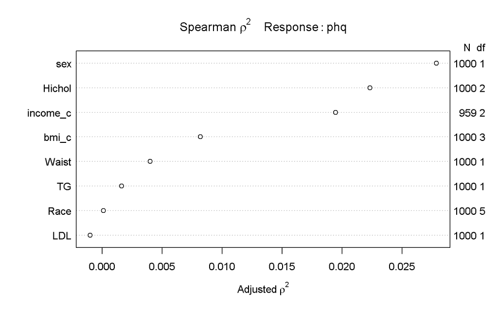

```r
plot(spearman2(phq ~ sex + Race + income_c + TG + LDL + Hichol + bmi_c + Waist, data = complete))
```

# 8 Task 8: Logistic Model Plans

We will predict the binary outcome **MHvisit** using the following 8 variables:

- `sex`
- `Race`
- `income_c`
- `TG`
- `LDL`
- `Hichol`
- `bmi_c`
- `Waist`

## 8.1 Spearman $\rho^2$ Plot

A Spearman $\rho^2$ plot suggests that `Race`, `bmi_c` may be important, but not the rest of the predictor variables.

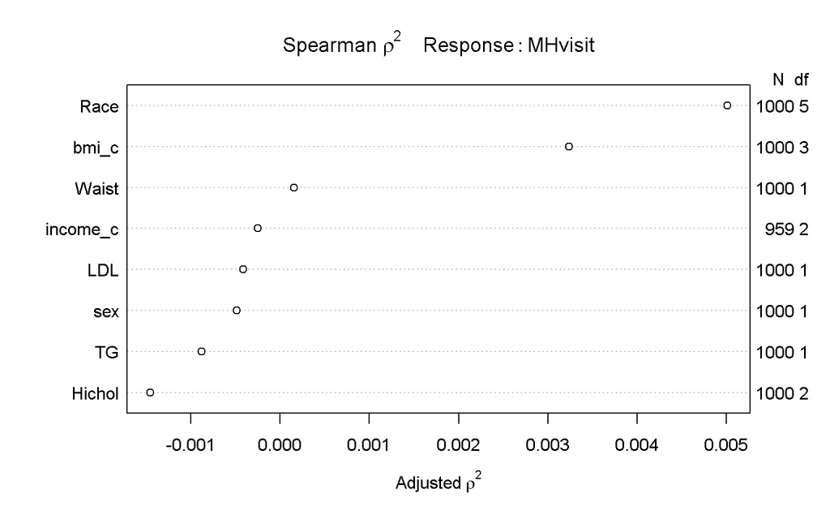

```r
plot(spearman2(MHvisit ~ sex + Race + income_c + TG + LDL + Hichol + bmi_c + Waist, data = complete))
```

# 9 Task 9: Affirmation

This data set meets all requirements specified in the project instructions.

- The data set contains 1000 observations on 17 variables, well within the limits of 100-1000 observations on 7-20 variables set in the assignment.
- We are considering at least four predictors for each regression model, and we include at least one quantitative (for example, `TG`) and multi-categorical variable (for example, `Race`) in each model.
- Dr. Love is certain that it is completely appropriate for these data to be shared with anyone, without any conditions. There are no concerns about privacy or security, mostly because the data have been on a public website for many years, and are completely free of identifying information about individual subjects.

Xin Xin Yu

2018-02-28 11:17:59